# Лабораторная работа № 11

Текстовой редактор emacs

Чжан Вэньцзюнь

Российский университет дружбы народов

РУДН

2026-10-20

# Информация

## Докладчик

- Чжан Вэньцзюнь
- зачётная книжка № 1132259051
- Российский университет дружбы народов им. П. Лумумбы

## Цель работы

- Знакомство с операционной системой Linux
- Получение практических навыков работы с редактором Emacs
- Освоение буферов, окон, поиска и замены

## Термины Emacs

- **Буфер** — объект, содержащий текст
- **Фрейм** — окно в обычном понимании
- **Окно** — область фрейма, показывающая буфер
- **Область вывода** — строки сообщений внизу
- **Минибуфер** — ввод дополнительной информации
- **Точка вставки** — позиция курсора в буфере

## Префиксные клавиши

- `C-` — Ctrl, `M-` — Meta/Alt/Esc, `S-` — Shift
- `C-x` — префикс основных команд
- `C-c` — префикс функций режима
- `M-x` — выполнение команды по имени
- `F10` — доступ к меню

# Выполнение работы

## Создание файла lab07.sh

```bash
emacs -nw
```

- `C-x C-f` — создание/открытие файла `~/work/os/lab07/lab07.sh`
- Набор текста скрипта
- `C-x C-s` — сохранение (сообщение `Wrote ...`)

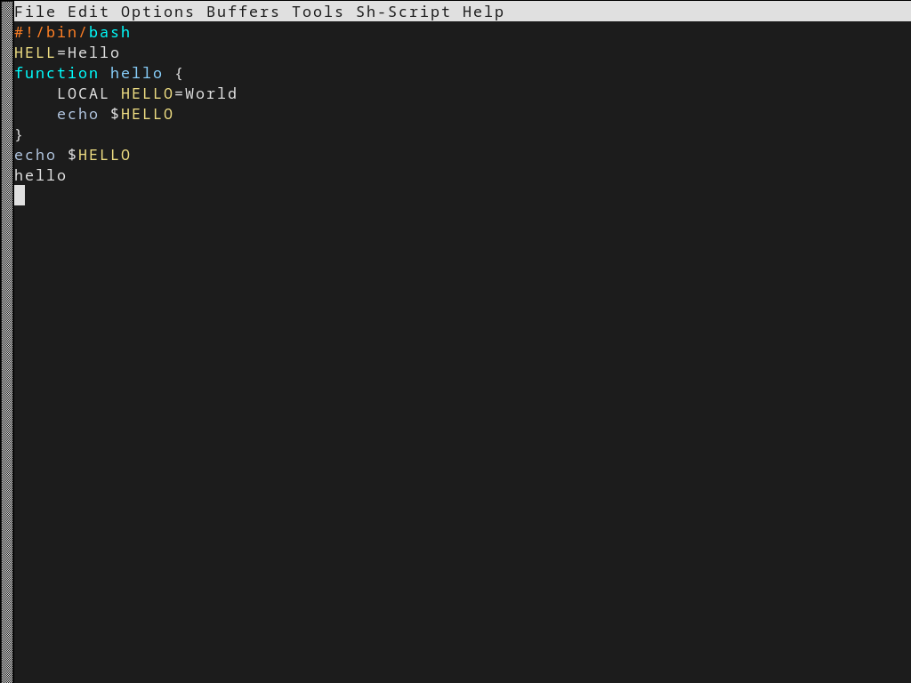

Главный экран Emacs с файлом lab07.sh

## Основные команды

| Действие | Клавиши |
| --- | --- |
| Вырезать строку | `C-k` |
| Вставить | `C-y` |
| Выделить область | `C-space` |
| Копировать область | `M-w` |
| Вырезать область | `C-w` |
| Отменить | `C-/` |
| Начало/конец строки | `C-a` / `C-e` |
| Начало/конец буфера | `M-<` / `M->` |

## Буферы и окна

- `C-x C-b` — список буферов
- `C-x b` — переключение буфера
- `C-x o` — переход в другое окно
- `C-x 0` — закрыть окно
- `C-x 3` — разделить по вертикали
- `C-x 2` — разделить по горизонтали

## Четыре окна

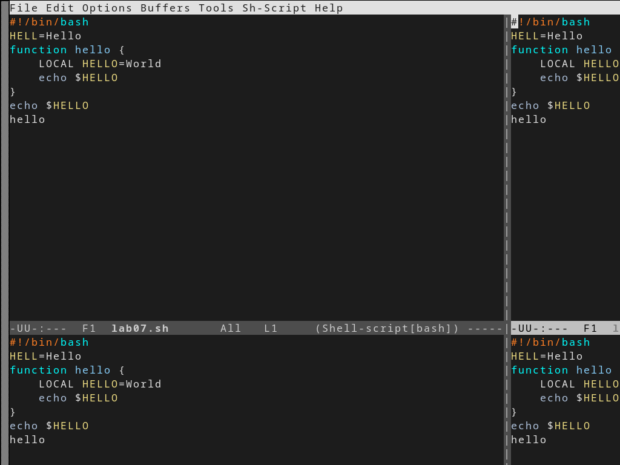

Фрейм, разделённый на четыре окна

## Поиск и замена

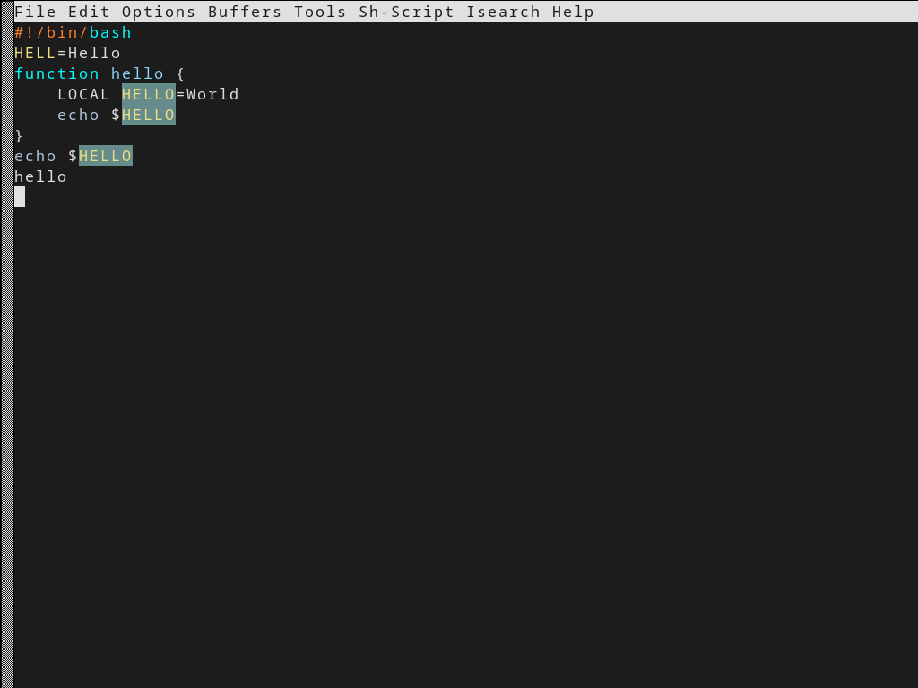

Инкрементальный поиск по шаблону HELLO

- `C-s` — инкрементальный поиск, `C-s` — следующее вхождение
- `C-g` — выход из режима поиска
- `M-%` — поиск с заменой, `!` — заменить все
- `M-s o` — обзор всех вхождений в отдельном буфере

# Заключение

## Выводы

- Изучена терминология Emacs: буфер, фрейм, окно, минибуфер
- Освоены комбинации перемещения курсора и редактирования
- Освоено управление буферами и окнами
- Освоены поиск (`C-s`) и замена (`M-%`, `M-s o`)
- Создан файл `lab07.sh`, фрейм разделён на 4 окна

## Спасибо за внимание!

Вопросы?